# CITS4009 project2

# Conclusion

Predicting the outcome of the injury (sum (Days away from work, Days restricted, Days charged)), all multiple variable models have reasonable performance, Logistic model performed the best. In this data set we remove narratives, this response variable may contain very important information to predict the outcome. Also we can use other model to predict the numerical lost rather than no lost and lost - such as linear regression, random forest and deep neural network.

# Part 2 - Clustering

functions to do K-clusters selection

```r
# Function to calculate squared distance
# between two vectors x and y
sqr_edist <- function(x, y) {
    sum((x-y)^2)
}

# Function to calculate WSS of a cluster
wss.cluster <- function(clustermat) {
    c0 <- apply(clustermat, 2, FUN=mean)
    sum(apply(clustermat, 1,
    FUN=function(row){sqr_edist(row,c0)}))
}

# Calculating the Total WSS
wss.total <- function(dmatrix, labels) {
    wsstot <- 0
    k <- length(unique(labels))
    for(i in 1:k){
        wsstot <- wsstot +
        wss.cluster(subset(dmatrix, labels==i))
    }
    wsstot
}

# Function to calculate total sum of squares
totss <- function(dmatrix) {
    grandmean <- apply(dmatrix, 2, FUN=mean)
            sum(apply(dmatrix, 1,
            FUN=function(row){sqr_edist(row, grandmean)}
        )
    )
}

# Function to calculate CH Index
ch_criterion <- function(d, kmax, method="kmeans") {
    if(!(method %in% c("kmeans", "hclust"))){
        stop("method must be one of c('kmeans', 'hclust')")
    }
    npts <- dim(d)[1] # number of rows.
    totss <- totss(d)
    wss <- numeric(kmax)
    crit <- numeric(kmax)
    wss[1] <- (npts-1)*sum(apply(d, 2, var))
    for(k in 2:kmax) {
        # d <- dist(dmatrix, method="euclidean")
        pfit <- hclust(as.dist(d), method="ward.D2")
        labels <- cutree(pfit, k=k)
        wss[k] <- wss.total(d, labels)
    }
    bss <- totss - wss
    crit.num <- bss/(0:(kmax-1))
    crit.num[1] <- 5
    crit.denom <- wss/(npts - 1:kmax)
    list(crit = crit.num/crit.denom, wss = wss, totss = totss)
}
```

#### Clean up some data, and divides some numerical data to ordinal data and only consider accdients causing (SCHEDULE_CHARGE + DAYS_LOST + DAYS_RESTRICT) > 0

```r
'%!in%' <- function(x,y)!('%in%'(x,y))
accidents <- read.csv("accidents.cleaned.csv") %>%
             mutate(risk = SCHEDULE_CHARGE + DAYS_LOST + DAYS_RESTRICT)
accidents <- accidents[which(accidents$NO_INJURIES>0 & accidents$risk>0 & accidents$DEGREE_INJURY %!in% c('ALL OTHER CASES (INCL 1ST AID)', 'INJURIES DUE TO NATURAL CAUSES', 'INJURIES INVOLVNG NONEMPLOYEES', 'OCCUPATNAL ILLNESS NOT DEG 1-6') & accidents$INJ_BODY_PART != 'UNCLASSIFIED'), 2:length(accidents)] %>%
             mutate(risk =  cut(risk, breaks=c(0, 50, 200, 500, Inf), labels = c('low risk', 'Midium risk', 'High risk', 'very High risk')))

for( n in colnames(accidents)){
  accidents <- accidents[which(accidents[, n]!="NO VALUE FOUND" & accidents[, n]!='UNKNOWN' & accidents[, n]!=""),]
}

for( n in c('TOT_EXPER.isbad', 'MINE_EXPER.isbad', 'JOB_EXPER.isbad')){
  accidents <- accidents[which(accidents[, n]!=1),]
}
```

only use OCCUPATION, ACTIVITY, INJURY_SOURCE, CLASSIFICATION, ACCIDENT_TYPE ,TOT_EXPER and custom variable risk to clustering Injury BODY_PART

```r
accidents <- accidents[,c('INJ_BODY_PART', 'OCCUPATION', 'ACTIVITY', 'INJURY_SOURCE', 'CLASSIFICATION', 'ACCIDENT_TYPE', 'TOT_EXPER', 'risk')] %>%
             mutate(TOT_EXPER=cut(TOT_EXPER, breaks=c(0, 3, 7, 12, 20, Inf),   labels = c('Entry Level', 'Mid level', 'senior level', 'Director level', 'Chief level')))
```

Using Cosine similarity to measure cohesion within INJ_BODY_PART:

```r
library(reshape2)
pivoted <- function(col){
    ff <- as.formula(paste('INJ_BODY_PART', col, sep=' ~ '))
    df <- dcast(data = accidents, formula = ff, fun.aggregate = length, value.var=col)
    row.names(df) <- df$INJ_BODY_PART
    df <- df[, 2:length(df)]
}
```

```r
tmp <- NULL
cos.sim <- function(DF){
    Matrix <- as.matrix(DF)
    as.dist(1 - Matrix%*%t(Matrix)/(sqrt(rowSums(Matrix^2) %*% t(rowSums(Matrix^2)))))
}
euclidean.sim <- function(DF) {
    Matrix <- as.matrix(DF)
    dist(Matrix, method = "euclidean")
}
manhattan.sim <- function(DF) {
    Matrix <- as.matrix(DF)
    dist(Matrix, method = "manhattan")
}

dfPivoted <- lapply(c('OCCUPATION', 'ACTIVITY', 'INJURY_SOURCE', 'CLASSIFICATION', 'ACCIDENT_TYPE', 'TOT_EXPER', 'risk'), pivoted)
names(dfPivoted) <- c('OCCUPATION', 'ACTIVITY', 'INJURY_SOURCE', 'CLASSIFICATION', 'ACCIDENT_TYPE', 'TOT_EXPER', 'risk')

# probability using
weight <- c( 0.05, 0.2, 0.15, 0.2, 0.2, 0.5, 0.15)
mesaure <- function(){
    d <- distances[[1]]* weight[1]
    for(i in 2:length(dfPivoted)){
        d <- d +  distances[[i]]* weight[i]
    }
    hfit <- hclust(as.dist(d), method = 'ward.D2')
    dendr <- dendro_data(hfit, type="rectangle")
    p<-ggplot() +
    geom_segment(data=segment(dendr), aes(x=x, y=y, xend=xend, yend=yend)) +
    geom_text(data=label(dendr), aes(x=x, y=y, label=label, hjust=0), size=3) +
    coord_flip() + scale_y_reverse(expand=c(0.2, 0)) +
    theme(axis.line.y=element_blank(),
            axis.ticks.y=element_blank(),
            axis.text.y=element_blank(),
            axis.title.y=element_blank(),
            text = element_text(size=8),
            panel.background=element_rect(fill="white"),
            panel.grid=element_blank())
    print(p)
    hfit
}
library(ggdendro)
```

Tried all the distance measure Euclidean , Manhattan and Cosine Similarity. The clusters produces by Cosine Similarity is most reasonable. This make sense as Cosine Similarity determine how similar the documents are irrespective of their size. In this context, we trying clustering which body parts relate to each other, and count how many time each words occurred. So even count is different, they could still have a smaller angle between them.

# plot the hierarchical cluster

```r
distances <- lapply(dfPivoted, cos.sim)
hfit.cos <- mesaure()
```

[figure not shown]

By viewing the graph we see Injure body parts to were classified to similar groups, for example the head part- (ear, face, jaw, nose mouth) in silimer group

```r
# distances <- lapply(dfPivoted, euclidean.sim)
# hfit.euclidean <- mesaure()
```

```r
# distances <- lapply(dfPivoted, manhattan.sim)
# hfit.euclidean <- mesaure()
```

### Extract members of each cluster using cutree()

```r
numCluster <-8
groups <- cutree(hfit.cos, k=numCluster)
print_clusters <- function(labels, k) {
    for(i in 1:k) {
        print(paste("cluster", i))
        cat('====================\n')
        cat(paste(names(groups[groups == i]), collapse = "\t"))
        cat('\n\n')
    }
}
print_clusters(groups, numCluster)
```

```
## [1] "cluster 1"
## ====================
## ABDOMEN/INTERNAL ORGANS  BACK (MUSCLES/SPINE/S-CORD/TAILBONE)    HIPS (PELVIS/ORGANS/KIDNEYS/BUTTOCKS)   SHOULDERS (COLLARBONE/CLAVICLE/SCAPULA) UPPER ARM/HUMERUS
##
## [1] "cluster 2"
## ====================
## ANKLE    BODY PARTS, NEC KNEE/PATELLA
##
## [1] "cluster 3"
## ====================
## ARM, MULTIPLE PARTS  ARM,NEC FINGER(S)/THUMB FOOT(NOT ANKLE/TOE)/TARSUS/METATARSUS   FOREARM/ULNAR/RADIUS    HAND (NOT WRIST OR FINGERS) LOWER EXTREMITIES,NEC   TOE(S)/PHALANGES    UPPER EXTREMITIES, MULTIPLE
##
## [1] "cluster 4"
## ====================
## BODY SYSTEMS
##
## [1] "cluster 5"
## ====================
## BRAIN    CHEST (RIBS/BREAST BONE/CHEST ORGNS)    ELBOW   LEG, MULTIPLE PARTS LEG, NEC    LOWER EXTREMITIES, MULTIPLE PARTS   LOWER LEG/TIBIA/FIBULA  MULTIPLE PARTS (MORE THAN ONE MAJOR)    NECK    SCALP   TRUNK, MULTIPLE PARTS   TRUNK,NEC   WRIST
##
## [1] "cluster 6"
## ====================
## EAR(S) EXTERNAL  EYE(S) OPTIC NERVE/VISON    FACE, MULTIPLE PARTS    FACE,NEC    HEAD, MULTIPLE PARTS    HEAD,NEC    JAW INCLUDE CHIN    MOUTH/LIP/TEETH/TONGUE/THROAT/TASTE NOSE/NASAL PASSAGES/SINUS/SMELL SKULL   THIGH/FEMUR
##
## [1] "cluster 7"
## ====================
## EAR(S) INTERNAL & EXTERNAL   EAR(S) INTERNAL & HEARING
##
## [1] "cluster 8"
## ====================
## UPPER EXTREMITIES, NEC
```

numCluster 8: based on analysis below

### interpretation

cluster 3 : contain injury body parts around non-lethal position cluster 5 : contain injury body parts may cause fatal and serious injury cluster 6": contain very board information around the head

## Visualising Cluster

Cuted tree

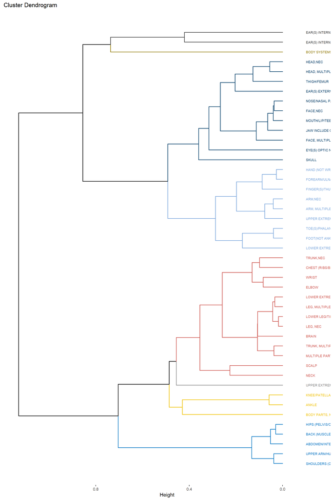

```r
library(factoextra)
hfit.cos %>% fviz_dend(cex = 0.5, k = 8, palette = "jco", horiz = TRUE)
```

```r
d <- distances[[1]]* weight[1]
for(i in 2:length(dfPivoted)){
    d <- d +  distances[[i]]* weight[i]
}
d <- as.matrix(d)
princ <- prcomp(d)
nComp <- 2
project <- as.data.frame(predict(princ, newdata=d)[,1:nComp])
project.plus <- cbind(project, cluster=as.factor(groups), bodyParts=names(groups))
```

```r
# finding convex hull
library('grDevices')
h <- do.call(
  rbind,
  lapply(
    unique(groups),
    function(c) {
    f <- subset(project.plus, cluster==c);
    f[chull(f),]
  })
)
```

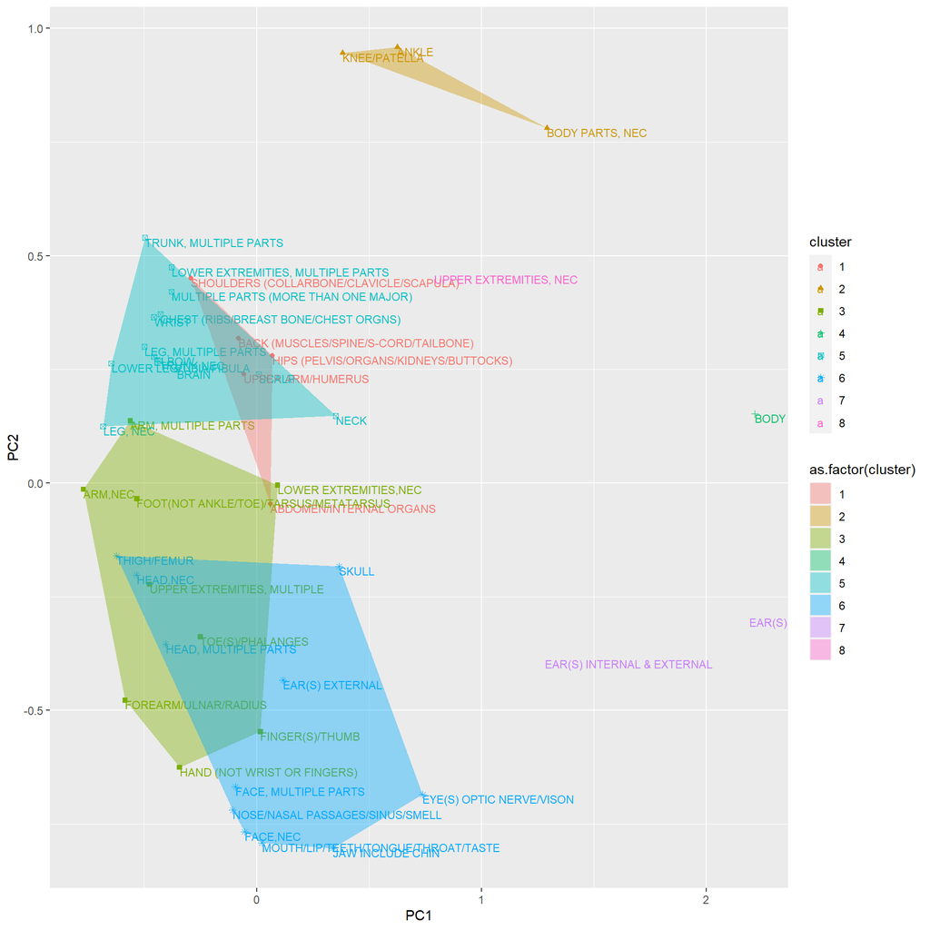

```r
ggplot(project.plus, aes(x=PC1, y=PC2)) +
  geom_point(aes(shape=cluster, color=cluster)) +
  geom_text(aes(label=bodyParts, color=cluster),
  hjust=0, vjust=1, size=3) +
  geom_polygon(data=h,
  aes(group=cluster,
  fill=as.factor(cluster)),
  alpha=0.4,linetype=0)
```

```r
library(fpc)
kbest.p <- numCluster
cboot.hclust <- clusterboot(
  d, clustermethod=hclustCBI,
  method="ward.D2", k=kbest.p)
```

[output not shown]

[output cut: 45 more lines]

[output not shown]

```r
summary(cboot.hclust$result)
```

```
##               Length Class  Mode
## result         7     hclust list
## noise          1     -none- logical
## nc             1     -none- numeric
## clusterlist    8     -none- list
## partition     45     -none- numeric
## clustermethod  1     -none- character
## nccl           1     -none- numeric
```

```r
groups <- cboot.hclust$result$partition
print_clusters(groups, numCluster)
```

```
## [1] "cluster 1"
## ====================
## ABDOMEN/INTERNAL ORGANS  BACK (MUSCLES/SPINE/S-CORD/TAILBONE)    HIPS (PELVIS/ORGANS/KIDNEYS/BUTTOCKS)   UPPER ARM/HUMERUS
##
## [1] "cluster 2"
## ====================
## ANKLE    BODY PARTS, NEC KNEE/PATELLA    UPPER EXTREMITIES, NEC
##
## [1] "cluster 3"
## ====================
## ARM, MULTIPLE PARTS  ARM,NEC BRAIN   CHEST (RIBS/BREAST BONE/CHEST ORGNS)    ELBOW   LEG, MULTIPLE PARTS LEG, NEC    LOWER EXTREMITIES, MULTIPLE PARTS   LOWER LEG/TIBIA/FIBULA  MULTIPLE PARTS (MORE THAN ONE MAJOR)    SHOULDERS (COLLARBONE/CLAVICLE/SCAPULA) THIGH/FEMUR TRUNK, MULTIPLE PARTS   TRUN…
##
## [1] "cluster 4"
## ====================
## BODY SYSTEMS
##
## [1] "cluster 5"
## ====================
## EAR(S) EXTERNAL  EYE(S) OPTIC NERVE/VISON    FACE, MULTIPLE PARTS    FACE,NEC    FINGER(S)/THUMB JAW INCLUDE CHIN    MOUTH/LIP/TEETH/TONGUE/THROAT/TASTE NOSE/NASAL PASSAGES/SINUS/SMELL
##
## [1] "cluster 6"
## ====================
## EAR(S) INTERNAL & EXTERNAL   EAR(S) INTERNAL & HEARING
##
## [1] "cluster 7"
## ====================
## FOOT(NOT ANKLE/TOE)/TARSUS/METATARSUS    FOREARM/ULNAR/RADIUS    HAND (NOT WRIST OR FINGERS) HEAD, MULTIPLE PARTS    HEAD,NEC    TOE(S)/PHALANGES    UPPER EXTREMITIES, MULTIPLE
##
## [1] "cluster 8"
## ====================
## LOWER EXTREMITIES,NEC    NECK    SCALP   SKULL
```

```r
cat('\nStability:\n')
```

```
##
## Stability:
```

```r
1-cboot.hclust$bootbrd/100
```

```
## [1] 0.85 0.85 0.90 0.50 0.88 0.53 0.62 0.86
```

## Selecting K based on Calinski-Harabasz index

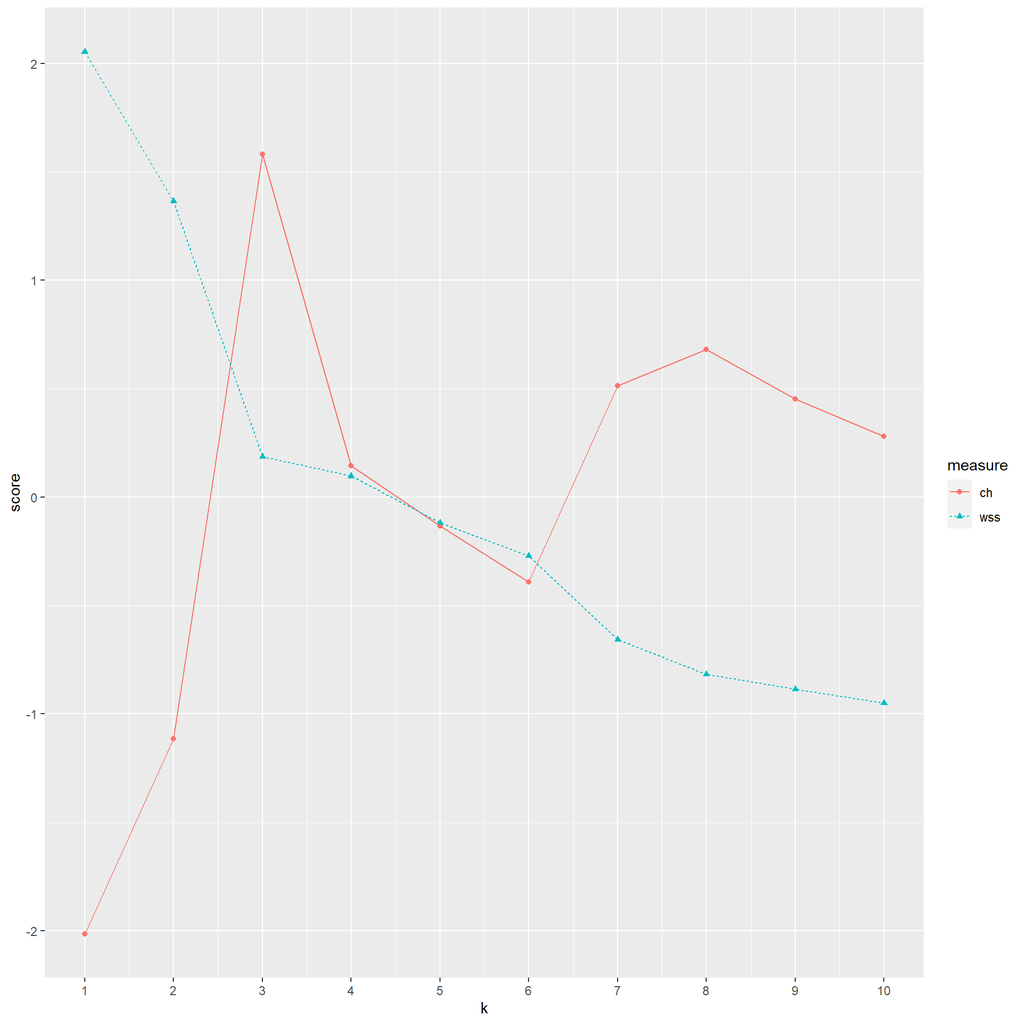

```r
k=10
clustcrit <- ch_criterion(d, k, method="hclust")

critframe <- data.frame(k=1:k, ch=scale(clustcrit$crit), wss=scale(clustcrit$wss))

critframe <- melt(critframe, id.vars=c("k"),
                  variable.name="measure",
                  value.name="score")

p<-ggplot(critframe, aes(x=k, y=score, color=measure)) +
          geom_point(aes(shape=measure)) +
          geom_line(aes(linetype=measure)) +
          scale_x_continuous(breaks=1:k, labels=1:k)
p
```

The smaller wss the better the cluster and the higher the ch the better the cluster

So we see, Ch index improved on k is 7 and 8

cluster is 3 is too small, so do not consider cluster

so pick 7 or 8 is reasonable

# Conclusions

Use cluster to group injury body parts Is feasible, similar Body parts were grouped into same group. And by further analysis the cluster result, workers can do more protection on a certain point based on the clustering result. But for multidimensional similarity clustering, a better way to pick weight vector may product better cluster result.